# Automatic analysis of exercise quality

### Machine learning, course project

## Synopsis

### The problem

The data used for this project has been downloaded here:

http://groupware.les.inf.puc-rio.br/har

Six young health participants were asked to perform one set of 10 repetitions of the Unilateral Dumbbell Biceps Curl in five different fashions - the correct one (Class A) and with a four typical mistakes (Classes B, C, D, E). The goal of our analysis is to construct a prediction algorithm to automatically determine the class using other 159 variables as predictors.

### Summary of analysis

I first looked at the given data and identified about 50 variables that were actually measured (the rest are either missing values or irrelevant things like the time of measurement). Then I constructed a simple decision tree several times based on a random subsample to identify the only 14 variables that affect the outcome.

Further, I split our data into a training set proper and a validation set, removed all the variables but the important 14 from the data and constructed a model based on boosting with trees. Its accuracy is 0.93. I used it to correctly guess 18 out of 20 test examplels.

Finally, I create a random forest model with accuracy about 0.99 and used it to correctly guess the remaining 2 test examples.

## Exploratory analysis and cleaning the data.

Downloading etc.:

```r
library(ggplot2)
library(knitr)
library(rpart)
library(caret)
library(lattice)
library(rpart.plot)
library(rattle)
library(plyr)
library(survival)

if (!file.exists("pml-training.csv")) {
        url <- "https://d396qusza40orc.cloudfront.net/predmachlearn/pml-training.csv"
        download.file(url,"pml-training.csv", method="curl")
}

if (!file.exists("pml-testing.csv")) {
        url <- "https://d396qusza40orc.cloudfront.net/predmachlearn/pml-testing.csv"
        download.file(url,"pml-testing.csv", method="curl")
}

D <- read.csv("pml-training.csv")
T <- read.csv("pml-testing.csv")
set.seed(2603)
```

The training set contains 19622 rows and the test set contains 20 rows.

Now we’ll remove the first 7 variables because they identify the subject, the time etc. - things not relevant to prediction).

```r
training <- D[,8:160]
testing <- T[,8:160]
types <- data.frame(var=names(testing),type=as.character(lapply(testing,class)))
head(types)
```

```
##                   var    type
## 1           roll_belt numeric
## 2          pitch_belt numeric
## 3            yaw_belt numeric
## 4    total_accel_belt integer
## 5  kurtosis_roll_belt logical
## 6 kurtosis_picth_belt logical
```

```r
head(testing[,1:8])
```

```
##   roll_belt pitch_belt yaw_belt total_accel_belt kurtosis_roll_belt
## 1    123.00      27.00    -4.75               20                 NA
## 2      1.02       4.87   -88.90                4                 NA
## 3      0.87       1.82   -88.50                5                 NA
## 4    125.00     -41.60   162.00               17                 NA
## 5      1.35       3.33   -88.60                3                 NA
## 6     -5.92       1.59   -87.70                4                 NA
##   kurtosis_picth_belt kurtosis_yaw_belt skewness_roll_belt
## 1                  NA                NA                 NA
## 2                  NA                NA                 NA
## 3                  NA                NA                 NA
## 4                  NA                NA                 NA
## 5                  NA                NA                 NA
## 6                  NA                NA                 NA
```

As we see, a lot of variables do not actually have any values. As it happens, only relevant variables are those numberic ones. We’ll re-define the training and the testing sets:

```r
relevant_var <- (types$type=='numeric')|(types$type=='integer')
training <- training[,relevant_var]
training$classe <- D$classe
testing <- testing[,relevant_var]
dim(training)
```

```
## [1] 19622    53
```

```r
dim(testing)
```

```
## [1] 20 53
```

## Decision tree that gives us important variables

Since the variable we are predicting is categorical, I won’t even look at algorithms related to linear models and build our analysis entirely on trees. We’ll construct a simple decision tree first to see which variables are imporant for prediction.

```r
modTree <- train(classe ~ ., method="rpart", data=training)
```

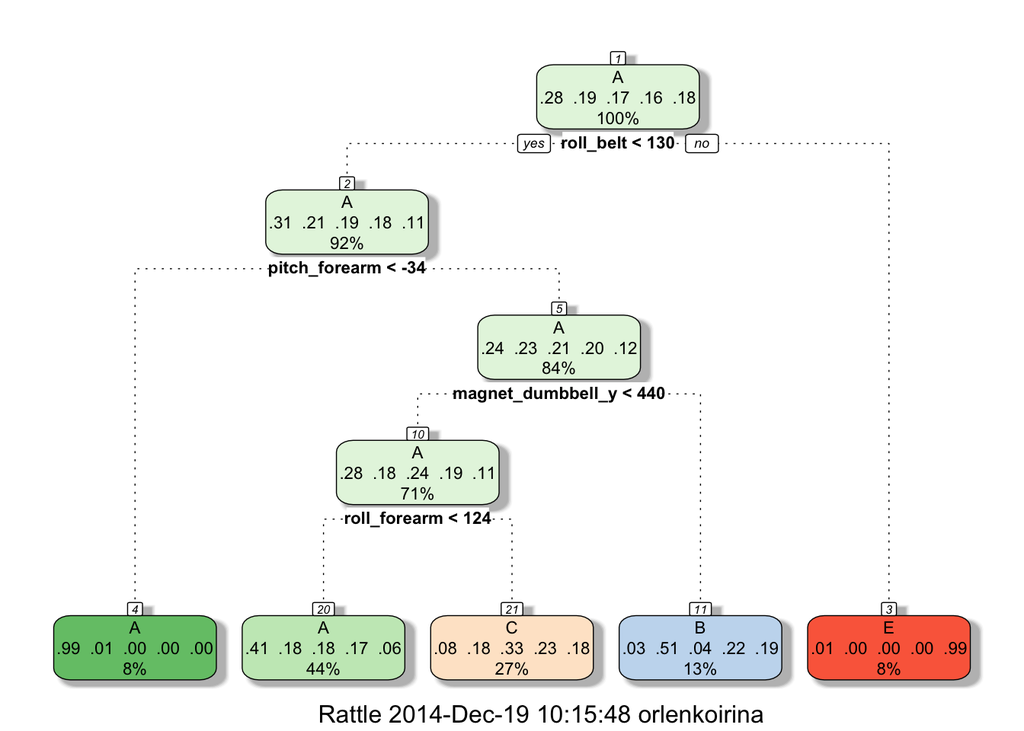

```r
fancyRpartPlot(modTree$finalModel)
```

```r
var.imp <- varImp(modTree)
print(var.imp)
```

```
## rpart variable importance
##
##   only 20 most important variables shown (out of 52)
##
##                   Overall
## pitch_forearm       100.0
## roll_forearm         73.0
## roll_belt            70.4
## magnet_dumbbell_y    49.5
## accel_belt_z         43.0
## magnet_belt_y        40.8
## yaw_belt             40.4
## magnet_dumbbell_z    36.4
## total_accel_belt     35.3
## magnet_arm_x         27.1
## accel_arm_x          26.3
## roll_dumbbell        18.7
## accel_dumbbell_y     15.6
## roll_arm             15.3
## gyros_forearm_y       0.0
## yaw_arm               0.0
## accel_arm_z           0.0
## accel_belt_x          0.0
## yaw_dumbbell          0.0
## gyros_belt_z          0.0
```

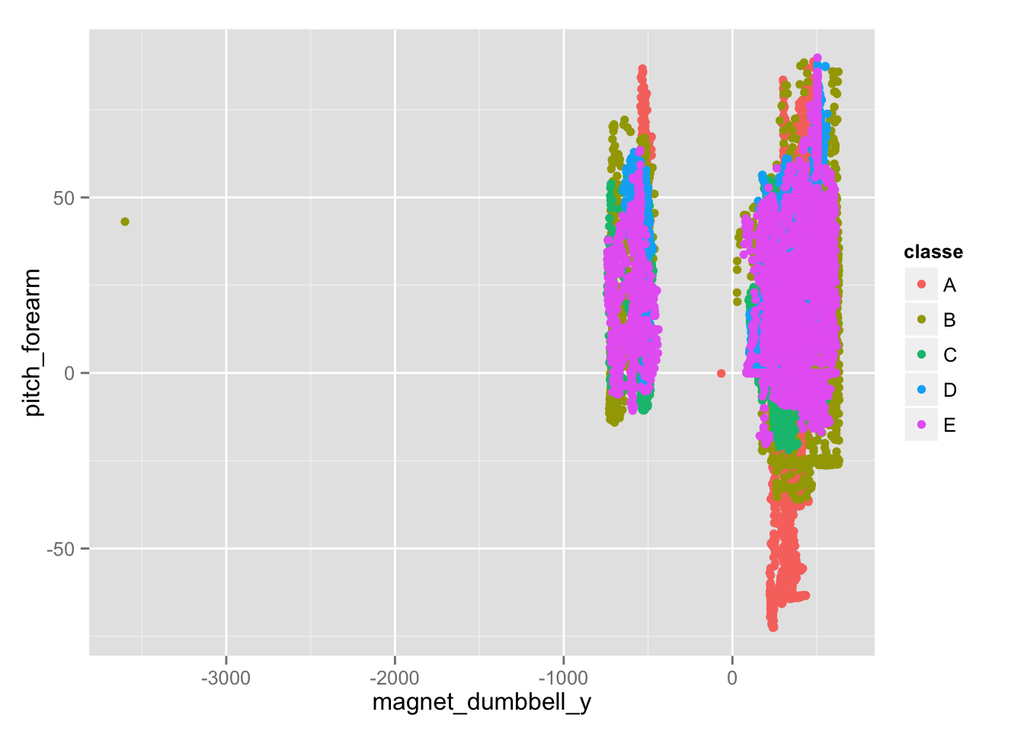

```r
good.var <- row.names(var.imp$importance)[1:14]
qplot(data=training, x=magnet_dumbbell_y, y=pitch_forearm, colour=classe)
```

However, any particular decision tree itself has a very low accuracy. We’ll try a boosting algorithm based on trees.

## The boosting model.

### Creating the model

I’ll use a ‘GBM’ model because it is also based on trees so it seems reasonable to combine it with the variables that we got from obtaining a simple decision tree.

First, we’ll remove all the variables but the relevant 14 and create a training subset and a validation set to be able to estimate the accuracy of our algorithm later.

```r
inTrain <- createDataPartition(y=training$classe,
                               p=0.7, list=FALSE)
training.set <- training[inTrain,]
validation.set <- training[-inTrain,]
dim(training.set)
```

```
## [1] 13737    53
```

```r
dim(validation.set)
```

```
## [1] 5885   53
```

```r
training.set <- training.set[,c(good.var,"classe")]
validation.set <- validation.set[,c(good.var,"classe")]
testing <- testing[,c(good.var,"problem_id")]
```

We’ll predict the class on the validation set and compare with the known answer:

```r
modGBM <- train(classe ~ ., method="gbm",data=training.set)
print(modGBM)

predictGBM <- predict(modGBM, newdata=validation.set)
C <- confusionMatrix(predictGBM,validation.set$classe)
```

[output not shown]

Here is the whole confusion matrix

```r
C$table
```

```
##           Reference
## Prediction    A    B    C    D    E
##          A 1620   43    2    5    1
##          B   23 1009   57    8   11
##          C   20   61  937   50    8
##          D   10   23   30  893   19
##          E    1    3    0    8 1043
```

## Random forest

I also constructed a random forest model with 0.99 accuracy and used it to correct the two answers that were guessed wrongly by the GBM algorithm. However, it takes a long time to actually construct it (20 minutes or so on my computer), so I won’t include it ito my analysis.

### System info

Our analysis has been originally created and run in RStudio v. 0.98.1080 under OS X 10.9.5.

Time and date the report has been generated: 2014-12-19 13:50:05 (Central European time).